# Data exploration PCA + variation plot

Linfeng Wang

12/04/2022

```r
knitr::opts_chunk$set(echo = TRUE)
knitr::opts_chunk$set(message = FALSE)
knitr::opts_chunk$set(fig.align = 'center')
knitr::opts_chunk$set(fig.width = 9)
knitr::opts_chunk$set(fig.height = 5)
#knitr::knit_hooks$set(rgl = hook_rgl)
```

```r
.libPaths("/home/linfeng/R/x86_64-pc-linux-gnu-library/3.4")

library(pacman)
library(datasets)
library(tidyverse)
library(VennDiagram)
library(devtools)
#library(MethylToSNP)
library(GGally)
library(ggfortify)
library(cowplot)
library(psych)
library(reshape)
library(IlluminaHumanMethylationEPICanno.ilm10b2.hg19)
# library(meffil)
library(missMethyl)
library(GenomicRanges)
library("VennDiagram")
library(readxl)
library(tidyverse)
library(ggvenn)
library(segmenter)
# library(Gviz)
library(ComplexHeatmap)
# library(TxDb.Hsapiens.UCSC.hg18.knownGene)
library(chromswitch)
library(rtracklayer)
library(annotatr)
library(boot)
library(plotrix)


pacman::p_load(pacman, dplyr, GGally, ggplot2, ggthemes,
               ggvis, httr, lubridate, plotly, rio, rmarkdown,
               shiny, stringr, tidyr)
```

```r
  setwd("/data/s1/fetal_EPIC_processed")
  EPIC.norm.beta<- readRDS("/data/s1/fetal_EPIC_processed/Beta_matrices/EPIC.norm.beta.RDS")
  SampleSheet_edited <- readRDS("/data/s1/fetal_EPIC_processed/samplesheets/SampleSheet_edited.RDS")

  EPIC.norm.beta <- as_tibble(EPIC.norm.beta)
  SampleSheet_edited <- as_tibble(SampleSheet_edited)
```

Running meffill analysis

```r
# options(mc.cores=6)
# path_to_idat_files = "/home/linfeng/IDAT_pool"
# samplesheet <- meffil.create.samplesheet(path_to_idat_files)
#
# beta <- meffil.normalize.dataset(samplesheet, qc.file="qc/report.html", author="Linfeng", study="EPIC array", number.pcs=10)
```

Function for removing NAs from dataframe and samplesheet

```r
df_processing <- function(EPIC.norm.beta){

  #put unique identifier as header for EPIC.norm.beta.DF
  list_ <- matrix(c(SampleSheet_edited$unique.identifier, SampleSheet_edited$Sample_Name),
                  nrow=2, ncol=dim(SampleSheet_edited)[1], byrow = TRUE)


  for (i in seq(1,length(colnames(EPIC.norm.beta)))){
    for (x in seq(1,length(list_[2,]))){
      if (colnames(EPIC.norm.beta)[i] == list_[2,][x]) {
        colnames(EPIC.norm.beta)[i] <- list_[1,][x]
      }
    }
  }

  #reorganize data, preparing for variance study, removing NA sample
  EPIC.norm.beta.DF <- as.data.frame(EPIC.norm.beta)

  EPIC.norm.beta.DF <-
    EPIC.norm.beta.DF %>%
    select(contains("S"))

  #graphing example individual
  # ggplot(EPIC.norm.beta.DF, aes(x = S48_brain_Ecto, y = S48_intestine_Endo)) +
  #   geom_point(alpha = 0.006)
  #
  # par(mar=c(1,1,1,1))
  # par("mar")

  #cor(EPIC.norm.beta.DF$S48_brain_Ecto, EPIC.norm.beta.DF$S48_intestine_Endo)

  print("EPIC.norm.beta.DF dim:")
  print(dim(EPIC.norm.beta.DF))

  return(EPIC.norm.beta.DF)

}

SS_processing <- function(SampleSheet_edited){

  SampleSheet_edited <- SampleSheet_edited %>% filter(Individual != "NANA")

  SampleSheet_edited <- SampleSheet_edited %>% #removing label whose data is missing in EPIC data array
  filter(unique.identifier != "S85_intestine_Endo") %>%
  filter(unique.identifier != "S54_brain_Ecto") %>%
  filter(unique.identifier != "S62_spine_Ecto")
  # sum(is.na(row)) #check for 0s
  # for (i in seq(1,length(m.values))){
  #   #print(i)
  #   print(sum(is.na(m.values[i])))
  # }
  print("SampleSheet dim:")
  print(dim(SampleSheet_edited))

  return(SampleSheet_edited)
}
```

```r
EPIC.norm.beta.DF <-  df_processing(EPIC.norm.beta)
```

```
[1] "EPIC.norm.beta.DF dim:"
[1] 865049     53
```

sex prediction visualisation from Beta value

```r
sex_beta <- melt(sex_beta)
```

# recorded sex chrY beta values

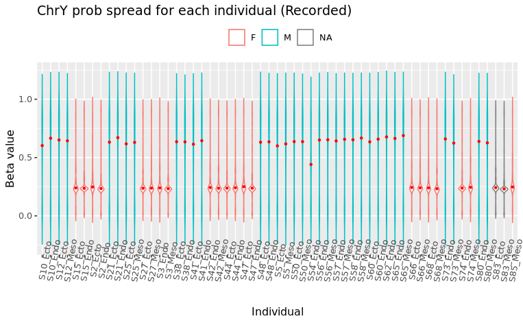

As can be seen in the graph the sex can be distinguished from the distribution of beta value as clearly indicated by the violin plot and the median value as labelled by the red dot.

The violin plot is graphed from chrY related probe beta value, as colored by recorded sex. As can be seen that the grey samples with NA for recorded sex can be correctly categorized by looking at the beta value distribution

```r
# Predicted sex from chrY beta values

# p <- ggplot(sex_beta, aes(x=variable, y=value, color=predicted_sex)) +
#   geom_violin(trim=FALSE)  +
#   scale_color_discrete(name=NULL) +
#   theme(legend.position="top", axis.text.x = element_text(angle = 30))
#
# p + stat_summary(fun=median, geom="point", size=0.8, color="red") +labs(title="ChrY prob spread for each individual (Predicted)",
#         x ="Individual", y = "Beta value")

#In predicted sex, meffil correctly labeled the missing data according to the beta value distribution
```

cross hybridised + SNP probe removal

```r
EPIC.norm.beta.DF <- crp.SNP.remove.func(EPIC.norm.beta.DF, crp)
```

```
[1] "No. of cross hybridised and snp probe removed:" "61522"
[1] "No. of CPG_rs probe removed:" "29964"
```

lm adjustion functions

```r
lm_zero_removal <- function(EPIC.norm.beta.DF){
    for (i in seq(1, length(EPIC.norm.beta.DF))){ #give 0 values a very small value
      print(c(i, "out of", length(EPIC.norm.beta.DF)))
      for (x in seq(1, length(EPIC.norm.beta.DF[,i]))){
        if(EPIC.norm.beta.DF[x,i]==0){
          EPIC.norm.beta.DF[x,i] = EPIC.norm.beta.DF[x,i] + 1e-14
          }
      }
    }
    return(EPIC.norm.beta.DF)
}


lm_adjustion_func <- function(EPIC.norm.beta.DF, SampleSheet_edited){

  print("===Taking variables===")
  # make sure the slide, row and column variables are factors
  slide = as.factor(SampleSheet_edited$Slide) #should not be adjusted for
  row= as.factor(SampleSheet_edited$sentrix_row)
  column = as.factor(SampleSheet_edited$sentrix_col) #only one level
  sex = as.factor(SampleSheet_edited$predicted.sex)
  age = as.factor(SampleSheet_edited$Gestational.age)

  print("===Converting to M values===")

  m.values <- log(EPIC.norm.beta.DF/(1-EPIC.norm.beta.DF)) #where beta rows are cpgs and columns are samples
  m.value.adj <- lm(t(m.values) ~ row + sex + slide) # make sure that the rownames of t(m.values) match the order of the samples that you extracted slide, row and column from

  print("===Converting back to beta===")
  inter <- coef(m.value.adj)[1,]
  res <- t(m.value.adj$residuals)
  meth.data.adj <- res + inter[row(res)] #why add the residual to intercept

  beta.adj <- exp(meth.data.adj)/(1+exp(meth.data.adj)) # transform from M values back to beta values
  beta.adj <- as.data.frame(beta.adj)
  rownames(beta.adj) <-rownames(EPIC.norm.beta.DF)

  return(beta.adj)
}
```

running of the lm_adjustion_function

```r
beta.adj <- lm_adjustion_func(EPIC.norm.beta.DF, SampleSheet_edited)
```

```
[1] "===Taking variables==="
[1] "===Converting to M values==="
[1] "===Converting back to beta==="
```

function for PCA analysis function calculated variance explained + PC

```r
#PCA analysis function calculated variance explained
pca_analysis_sdev <- function(beta_df){
  print("===PCA analysis===")
  beta.pca <- prcomp(t(beta_df), scale= TRUE)
  print("===PCA ratio calculation===")
  var_explained <- as.data.frame(beta.pca$sdev^2 / sum(beta.pca$sdev^2)) %>% add_column(seq(1, length(beta_df)))
  print("===Graphing Scree plot===")
  colnames(var_explained) <- c('PC', 'sample')
  p2 <- ggplot(var_explained, aes(x=sample, y=PC)) +
    geom_bar(stat='identity') +
    xlab("Principal Component") +
    ylab("Variance Explained") +
    ggtitle("Scree Plot")
    # ylim(0, 1)
  p2 + theme(axis.text.x = element_text(angle = 45, hjust = 1))  +
        ggtitle("PCA analysis - variance explained") + ylim(0,0.23)
  # scale_y_continuous(trans = "log10", limits = c(0, 1))
}

#PCA analysis function calculating Principle component
pca_analysis_PC <- function(beta_df){
  print("===PCA analysis===")
  beta.pca <- prcomp(t(beta_df), scale= TRUE)
  var_explained <- as.data.frame(beta.pca$sdev^2 / sum(beta.pca$sdev^2)) %>% add_column(colnames(beta_df))

  print("===Graphing dot plot===")
  beta.pca$x %>%
  as.data.frame %>%
  ggplot(aes(x=PC1,y=PC2)) + geom_point(alpha=0.6) + theme_bw(base_size=32) +
  labs(x=paste0("PC1: ",round(var_explained[[1]][1]*100,1),"%"),
       y=paste0("PC2: ",round(var_explained[[1]][2]*100,1),"%")) +
  theme(legend.title = element_text(size=15),
        legend.text = element_text(size=10),
        axis.text=element_text(size=12),
        axis.title=element_text(size=14,face="bold")) +
        ggtitle("PCA analysis - PC")
}
```

# PCA

removing outliers

```r
# beta_PC %>% filter(PC1 < -1500) %>%  select(c(PC1, unique_label, sex, row, slide))


beta.adj <- beta.adj %>% select(c(-S54_lung_Endo, -S2_skin_Ecto))
SampleSheet_edited <- SampleSheet_edited %>% filter(unique.identifier != "S54_lung_Endo") %>% filter(unique.identifier != "S2_skin_Ecto")
```

## All samples (adjusted data) - variance explaind

```
[1] "===PCA analysis==="
[1] "===PCA ratio calculation==="
[1] "===Graphing Scree plot==="
```

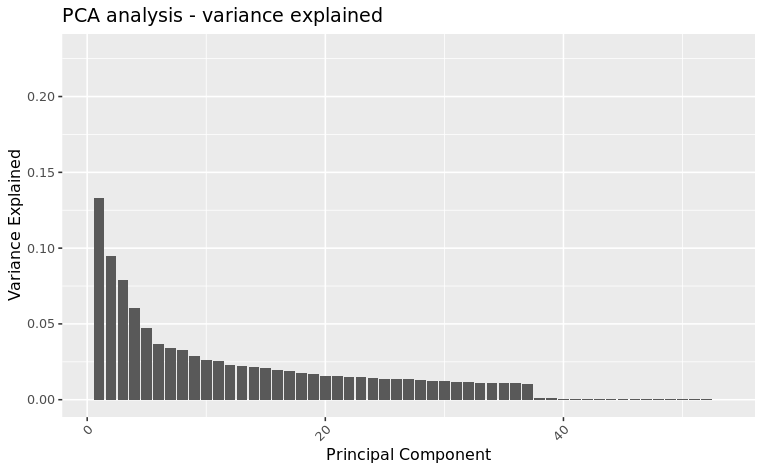

```r
pca_analysis_sdev(beta.adj)
```

## All samples (adjusted data) - PC

```
[1] "===PCA analysis==="
[1] "===Graphing dot plot==="
```

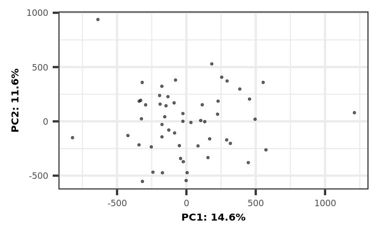

```r
pca_analysis_PC(beta.adj)
```

They are: S54_lung_Endo -2253.399 S54_lung_Endo M 05 204088030103 v -1749.628 S2_skin_Ecto F 01 203982200068

It also shows that there is redundancy in the data. This redundancy proves that PCA may be used to reduce the original data into a smaller number of new variables. After the removal of outliers, there has been a drecrease in variation by PC1

Data organisation for producing PC plots with colour

```r
beta.pca <- prcomp(t(beta.adj), scale= TRUE)

beta_PC <-beta.pca$x %>% as.data.frame()

beta_PC$germlayer= 0
beta_PC$tissue= 0
beta_PC$unique_label= 0
beta_PC$gestation2w= 0
beta_PC$gestation3w= 0
beta_PC$sex= 0
beta_PC$slide= 0
beta_PC$row= 0


for (i in seq(1, length(beta.adj))){
  temp <- as.list(strsplit(colnames(beta.adj)[i], split="_"))[[1]]
  beta_PC$germlayer[i] <- temp[3]
  beta_PC$tissue[i] <- temp[2]
  beta_PC$unique_label[i] <- colnames(beta.adj)[i]

}
# -2 is to minus the two outliers
list_ <- matrix(c(SampleSheet_edited$unique.identifier, SampleSheet_edited$Gestational.age),
                  nrow=2, ncol=dim(SampleSheet_edited)[1], byrow = TRUE)

for (i in seq(1,length(list_[2,]))){
  if (is.na(list_[2,i])) {list_[2,i] <- 'Missing'}
  else if (list_[2,i] == "9" | list_[2,i] == "9-10" ) {list_[2,i] <- "9-10"}
  else if (list_[2,i] == "10" | list_[2,i] == "10-11" ) {list_[2,i] <- "10-11"}
  else if (list_[2,i] == "11" | list_[2,i] == "11-12" ) {list_[2,i] <- "11-12"}
  else if (list_[2,i] == "12" | list_[2,i] == "12-13" | list_[2,i] == "14" | list_[2,i] == "15" | list_[2,i] == "16")
    {list_[2,i] <- "12-16"}
  else if (list_[2,i] == "17" | list_[2,i] == "18" ) {list_[2,i] <- "17-18"}
  else {print(list_[2,i])}
}

beta_PC$gestation2w <- list_[2,]

beta_PC %>% dim()
```

```
[1] 53 61
```

```r
list_ %>%  dim()
```

```
[1]  2 53
```

```r
list_ <- matrix(c(SampleSheet_edited$unique.identifier, SampleSheet_edited$Gestational.age),
                  nrow=2, ncol=dim(SampleSheet_edited)[1], byrow = TRUE)

for (i in seq(1,length(list_[2,]))){
  if (is.na(list_[2,i])) {list_[2,i] <- 'Missing'}
  else if (list_[2,i] == "9" | list_[2,i] == "9-10" | list_[2,i] == "10" |list_[2,i] == "10-11" ) {list_[2,i] <- "9-11"}
  else if (list_[2,i] == "11" | list_[2,i] == "11-12" | list_[2,i] == "12" | list_[2,i] == "12-13" ) {list_[2,i] <- "11-13"}
  else if (list_[2,i] == "14" | list_[2,i] == "16" ) {list_[2,i] <- "14-16"}
  else if (list_[2,i] == "17" | list_[2,i] == "18" ) {list_[2,i] <- "17-18"}
  else {print(list_[2,i])}
}

beta_PC %>% dim()
```

```
[1] 53 61
```

```r
beta_PC$gestation3w <- list_[2,]
beta_PC %>%  group_by(gestation3w) %>% summarise("number" = n())
```

| gestation3w | number |
| --- | --- |
| 11-13 | 11 |
| 14-16 | 8 |
| 17-18 | 9 |
| 9-11 | 25 |

```r
beta_PC$sex <- SampleSheet_edited$predicted.sex
beta_PC$row <- SampleSheet_edited$sentrix_row
beta_PC$slide <- SampleSheet_edited$Slide
```

## Summary histogram for original gestational age and count

Shows that the number of the in each gestational age is unequal the missing columns are umbiguous age: e.g. the column between 10 and 11 and 10-11

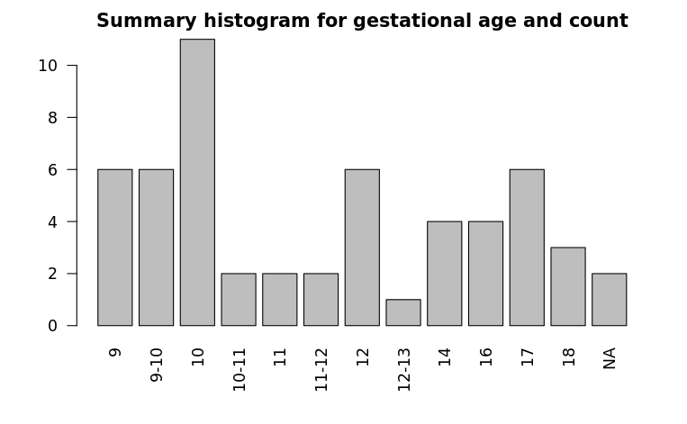

## Summary table for tissue and germlayer

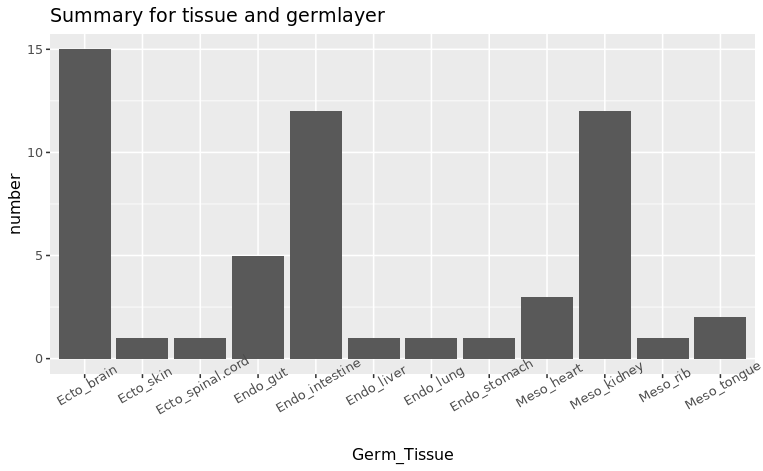

The values with the highest counts are Ecto_brain, Endo_intestine, Meso_kidney.

## PC - colored by Germlayer

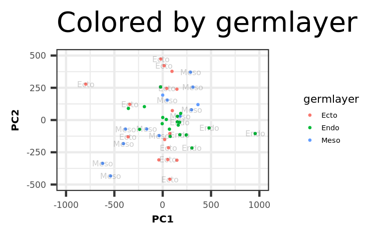

```r
ggplot(beta_PC, aes(x=PC1,y=PC2)) + geom_point(aes(color=germlayer)) + theme_bw(base_size=32) +
  theme(legend.title = element_text(size=15),
        legend.text = element_text(size=10),
        axis.text=element_text(size=12),
        axis.title=element_text(size=14,face="bold"))+
  geom_text(
    label=beta_PC$germlayer,
    nudge_x = 0.25, nudge_y = 0.25,
    check_overlap = T,
    alpha = 0.2
  ) +
  ggtitle("Colored by germlayer") +
  xlim(-1000,1000) + ylim(-500, 500)
```

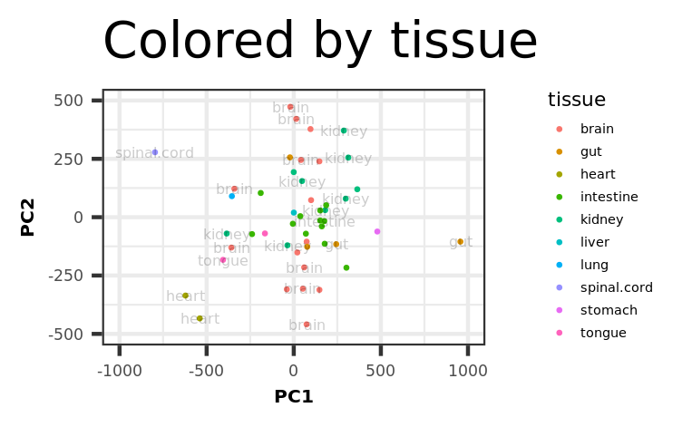

```r
ggplot(beta_PC, aes(x=PC1,y=PC2)) + geom_point(aes(color=tissue)) + theme_bw(base_size=32) +
  theme(legend.title = element_text(size=15),
        legend.text = element_text(size=10),
        axis.text=element_text(size=12),
        axis.title=element_text(size=14,face="bold"))+
  geom_text(
    label=beta_PC$tissue,
    nudge_x = 0.25, nudge_y = 0.25,
    check_overlap = T,
    alpha = 0.2
  ) +
  ggtitle("Colored by tissue") +
  xlim(-1000,1000) + ylim(-500, 500)
```

After adjusting for slide: the tripartisan distribution is not as clearly seem.

## PC - colored by Gestational Age (2 weeks)

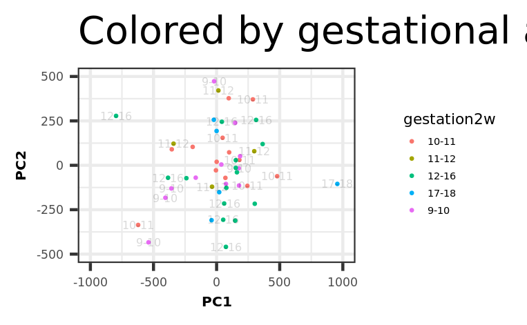

```r
ggplot(beta_PC, aes(x=PC1,y=PC2)) + geom_point(aes(color=gestation2w)) + theme_bw(base_size=32) +
  theme(legend.title = element_text(size=15),
        legend.text = element_text(size=10),
        axis.text=element_text(size=12),
        axis.title=element_text(size=14,face="bold"))+
  geom_text(
    label=beta_PC$gestation2w,
    nudge_x = 0.25, nudge_y = 0.25,
    check_overlap = T,
    alpha = 0.15
  ) +
  ggtitle("Colored by gestational age (2w)")+
  xlim(-1000,1000) + ylim(-500, 500)
```

## PC - colored by Gestational Age (3 weeks)

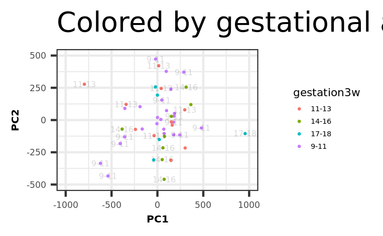

```r
ggplot(beta_PC, aes(x=PC1,y=PC2)) + geom_point(aes(color=gestation3w)) + theme_bw(base_size=32) +
  theme(legend.title = element_text(size=15),
        legend.text = element_text(size=10),
        axis.text=element_text(size=12),
        axis.title=element_text(size=14,face="bold")) +
  geom_text(
    label=beta_PC$gestation3w,
    nudge_x = 0.25, nudge_y = 0.25,
    check_overlap = T,
    alpha = 0.15
  ) +
  ggtitle("Colored by gestational age (3w)") +
  xlim(-1000,1000) + ylim(-500, 500)
```

## PC - colored by Sex

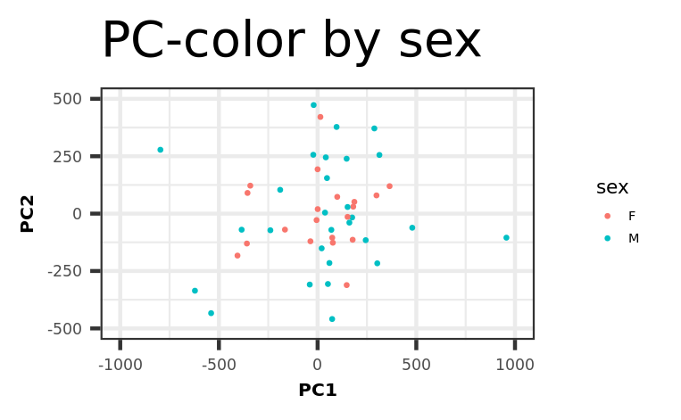

```r
ggplot(beta_PC, aes(x=PC1,y=PC2)) + geom_point(aes(color=sex)) + theme_bw(base_size=32) +
  theme(legend.title = element_text(size=15),
        legend.text = element_text(size=10),
        axis.text=element_text(size=12),
        axis.title=element_text(size=14,face="bold"))+
        ggtitle("PC-color by sex") +
        xlim(-1000,1000) + ylim(-500, 500)
```

## PC - colored by row

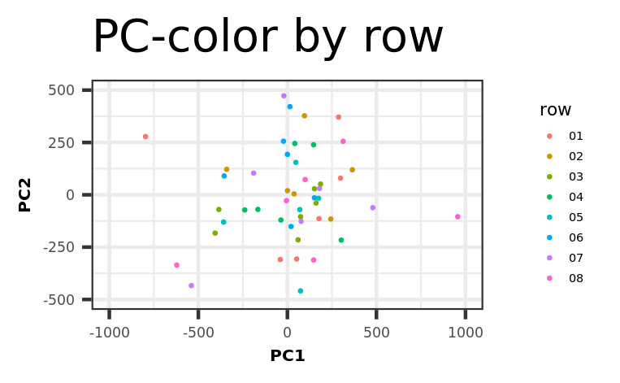

```r
ggplot(beta_PC, aes(x=PC1,y=PC2)) + geom_point(aes(color=row)) + theme_bw(base_size=32) +
  theme(legend.title = element_text(size=15),
        legend.text = element_text(size=10),
        axis.text=element_text(size=12),
        axis.title=element_text(size=14,face="bold"))+
        ggtitle("PC-color by row") +
        xlim(-1000,1000) + ylim(-500, 500)
```

## PC - colored by slide

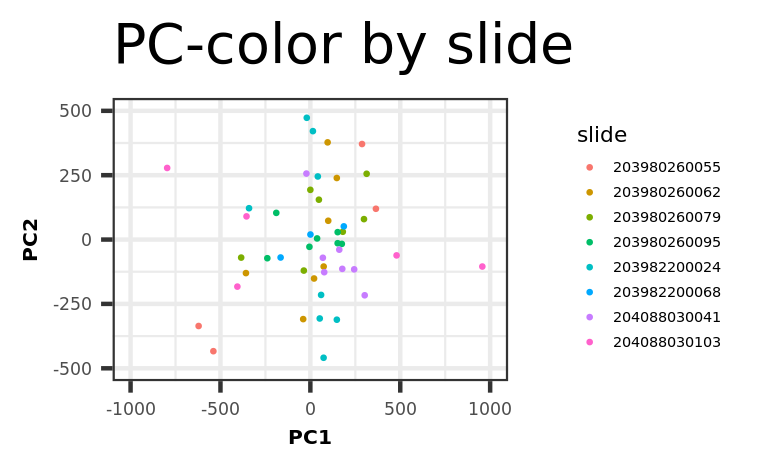

```r
ggplot(beta_PC, aes(x=PC1,y=PC2)) + geom_point(aes(color=slide)) + theme_bw(base_size=32) +
  theme(legend.title = element_text(size=15),
        legend.text = element_text(size=10),
        axis.text=element_text(size=12),
        axis.title=element_text(size=14,face="bold")) +
        ggtitle("PC-color by slide") +
        xlim(-1000,1000) + ylim(-500, 500)
```

Beta distribution as a histogram

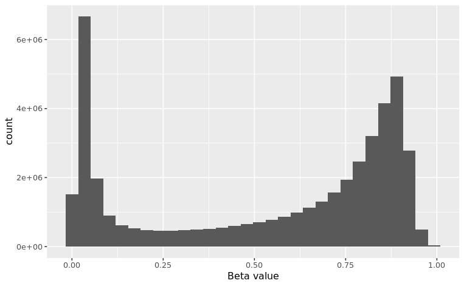

```r
ggplot(EPIC.norm.beta.DF.long, aes(x = value)) +    # Draw each column as histogram
  geom_histogram()+ xlab("Beta value")
```

```r
beta.adj.long <- beta.adj %>%                          # Apply pivot_longer function
  pivot_longer(colnames(beta.adj)) %>%
  as.data.frame()

ggplot(beta.adj.long, aes(x = value)) +    # Draw each column as histogram
  geom_histogram(color="white")
```

SampleSheet serialised

```r
SampleSheet.serialised %>% dim()
```

```
[1] 55  7
```

batchPCAcorr function

```r
#batchPCAcorr
batchPCAcorr <- function(pcs=NULL,batch=NULL,npcs=10){
  res <- matrix(nrow=ncol(batch),ncol=npcs,dimnames=list(colnames(batch),colnames(pcs)))
  #ensure samples are in the same order
  if(!(all.equal(rownames(pcs),rownames(batch)))){
    stop("samples must the same in both PC and batch variable data (i.e. rows should be equivalent)")
    }
  #iterate through batch vars and PCs running the relevant test for association
  for(m in rownames(res)){
    cat <- ifelse(length(levels(batch[,m]))==2,TRUE,FALSE)
      for(n in colnames(res)){
        if(cat){
          res[m,n] <- (pcs[,n] ~ batch[,m])$p.value
          }else if(!(cat)){
            if(typeof(levels(batch[,m]))!= "NULL"){
              res[m,n] <- kruskal.test(pcs[,n] ~ batch[,m])$p.value
              }else{
               #fit <- lm(pcs[,n] ~ batch[,m])
               #res[m,n] <- summary.lm(fit)$coefficients[2,4]
                  res[m,n] <- cor.test(pcs[,n],batch[,m],method='spearman',
                                 exact=F,continuity=T)$p.value
        }
        }
      }
    }
  return(res)
}
```

Generating PCA - variable probability plot

```r
SampleSheet.serialised %>% class()
```

```
[1] "data.frame"
```

## Correlation P value plot between PC and different variables

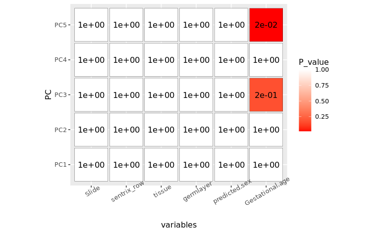

#variation visualisation function

## Applied version of variation calculation - No average, just substraction and find max

```r
var_func1 <- function(beta.adj){
  #calculating interindividual variation function
  print("===calculating interindividual variation===")
  #removing non-pair single samples  -  S2_liver_Endo is removed because it is singled out after outlier removal
  singles.removed <- beta.adj[,order(names(beta.adj))]  %>% select(c(-S85_kidney_Meso, -S62_intestine_Endo, -S2_liver_Endo))
  # singles.removed <- beta.adj[,order(names(beta.adj))]  %>% select(c(-S85_kidney_Meso, -S62_intestine_Endo, -S54_lung_Endo)) #before removal of the outlier S54_lung_Endo and S2_skin_Ecto
  rownames(singles.removed) <- rownames(beta.adj)

  individual_variation <- matrix(ncol = 0, nrow = dim(singles.removed)[1]) %>% as.data.frame()
  #average value for tissue within each individual
  for (a in seq(1,length(colnames(singles.removed)), by=2)){
    b = a+1
    individual_variation <- individual_variation %>% add_column((singles.removed[a]+singles.removed[b])/2)
  }
  # for each probe, individual with max variation - individual with min variation
  individual_variation[, "interindividual_var"] <-
  apply(individual_variation[, 1:ncol(individual_variation)], 1, max) - apply(individual_variation[, 1:ncol(individual_variation)], 1, min)


  #tissue variation calculation

  print("===calculating germ layer variation with in an individual===")

  germ_variation <- matrix(ncol = 0, nrow = dim(singles.removed)[1]) %>% as.data.frame()

  i <- 0

  for (a in seq(1,length(colnames(singles.removed)), by=2)){
    i <- i+1
    b <-  a+1
    germ_variation <- germ_variation %>% add_column((abs(singles.removed[a]-singles.removed[b])))

    germ1 <- as.list(strsplit(colnames(singles.removed[a]), split="_"))[[1]]
    germ2 <- as.list(strsplit(colnames(singles.removed[b]), split="_"))[[1]]
    #pair wise inter tissue difference calculation
    names(germ_variation)[i] <- paste(germ1[[1]],germ1[[3]],germ2[[3]],sep="_")
  }
  # head(germ_variation)

  print("===calculating mean of intergerm layer variation variation for each probe===")
  #Gather the germlayer difference together

  germ.diff.mean <- matrix(ncol = 0, nrow = dim(singles.removed)[1]) %>% as.data.frame()

  #get the max of the germlayer pair difference
  # n <- length(germ_variation)
  # sort(germ_variation,partial=n-1)[n-1]

  germ.diff.mean[, "germ_var"] <- apply(germ_variation, 1, max)



  print("===Final processes===")
  variationVB <- matrix(ncol=0, nrow=dim(germ.diff.mean)[1]) %>% as.data.frame()

  # print("==========")
  # print(colnames(variationVB))
  # print("==========")

  variationVB <- variationVB %>% add_column(rownames(singles.removed))
  variationVB <- variationVB %>% add_column(individual_variation$interindividual_var)
  variationVB <- variationVB %>% add_column(germ.diff.mean$germ_var)
  # variationVB <- variationVB %>% add_column(germ.diff.mean$Ecto_Endo)
  # variationVB <- variationVB %>% add_column(germ.diff.mean$Endo_Meso)
  # variationVB <- variationVB %>% add_column(germ.diff.mean$Meso_Ecto)

  names(variationVB) <- c("probes", "interindividual_var", "germ_var")

  # print("==========")
  # print(colnames(variationVB))
  # print("==========")

  print("===Done!===")

  return(variationVB)
}
```

## Summary table for tissue and germlayer

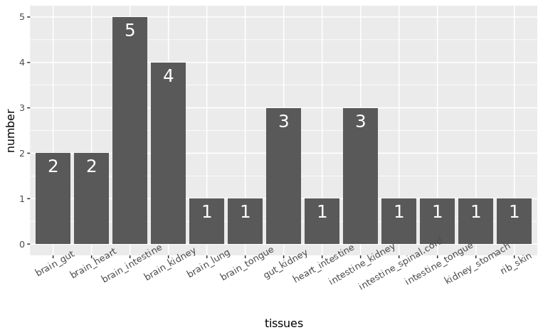

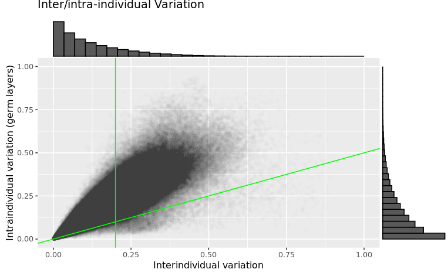

```r
variance_vis_func(variationVB)
```

```r
# rownames(beta.adj[,order(names(beta.adj))]  %>% select(c(-S85_kidney_Meso, -S62_intestine_Endo, -S54_lung_Endo)))
#
# rownames(beta.adj %>% select(c(-S85_kidney_Meso, -S62_intestine_Endo, -S54_lung_Endo)))
#
# beta.adj %>% select(c(-S85_kidney_Meso, -S62_intestine_Endo, -S54_lung_Endo)) %>%  rownames()
```

## boxplot showing intra-individual variation

```r
boxplot(variationVB[4:6])
```

[output not shown]

## Top10% percent of inter individual variance

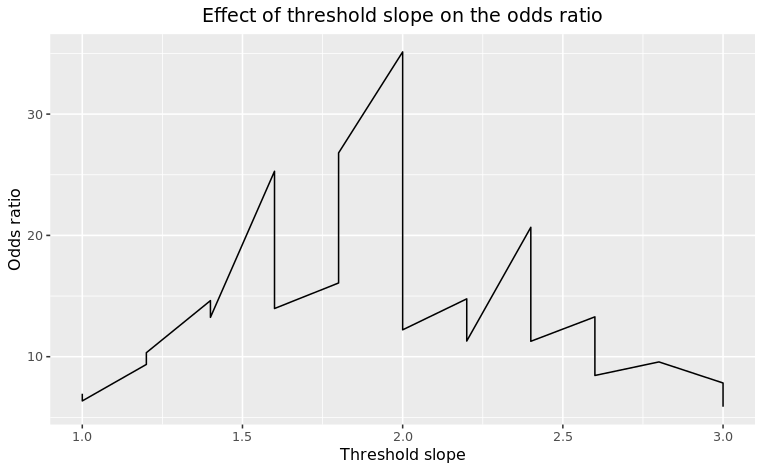

#implementation of result from the above graph

```r
identified.siv %>% length()
```

```
[1] 5464
```

#Loading established SIV, CpGs

```r
# 450k ME probes from Van Baak et al, Gen Biol 2017
# SIV
siv.cpgs = readRDS('~/SIV_ESS/SIV_unflitered_cgs.RDS')
#siv.cpgs = readRDS(file = 'SIV_filtered_cgs.RDS') #856
# ESS
ess.cpgs = readRDS("~/SIV_ESS/ess_unflitered_cgs.RDS")
#ess.cpgs = readRDS(file = 'ess_filtered_cgs.RDS') #1184

# MEs from WGBS screen (filtered list of 675 MEs published in Kessler et al Science Advances, 2018)
# this is true genome-wide data, so relatively few MEs intersect the EPIC array....
me.wgbs.gr = readRDS("~/SIV_ESS/ME.clusters.0.15_inter.1_3_intra.SNP_60.50_to_300_gap.67_prop.RDS")

# extract EPIC CpGs from the WGBS MEs
ME.clusters.0.15_inter.1_3_intra.SNP_60.50_to_300_gap.67_prop = readRDS("/mnt/ing-s1/EMPHASIS/EMPHASIS_EPIC/gambia/EPIC_manifest/cpglocs.epic.gr.RDS")
me.epic.wgbs = subsetByOverlaps(epic.cpgs.gr,ME.clusters.0.15_inter.1_3_intra.SNP_60.50_to_300_gap.67_prop)$cpg

# all me cpgs
me.cpgs = Reduce(union, list(ess.cpgs, siv.cpgs, me.epic.wgbs))
```

#Finding intersect between identidied siv and established siv

```r
siv.cpgs %>% length()
```

```
[1] 1042
```

```r
Foetal_ICH_beta_mat_adjusted_450k <- readRDS("/data/s1/fetal_EPIC_processed/Beta_matrices/Foetal_ICH_beta_mat_adjusted_450k.RDS")

k450.rowname <- Foetal_ICH_beta_mat_adjusted_450k %>%  row.names()
GO.background = Reduce(intersect, list(row.names(EPIC.norm.beta.DF), k450.rowname))
```

# Enrichment Study-GO

```
All input CpGs are used for testing.
```

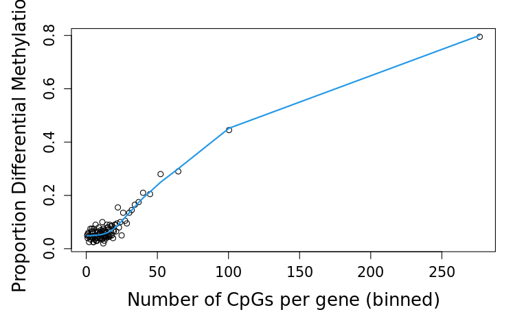

```r
gst <- gometh(sig.cpg=identified.siv, all.cpg=GO.background, collection="GO", array.type="EPIC", prior.prob = T, sig.genes = T, plot.bias=TRUE)
```

## topGSA(gst, n=10)

|  | ONTOLOGY | TERM | N | DE | P.DE | FDR | SigGenesInSet |
| --- | --- | --- | --- | --- | --- | --- | --- |
| GO:2001239 | BP | regulation of extrinsic apoptotic signaling pathway in absence of ligand | 41 | 7 | 0.0000923884 | 1 | AKT1,EYA4,FGFR1,IFI6,IL1B,ZC3HC1,WWOX |
| GO:0031663 | BP | lipopolysaccharide-mediated signaling pathway | 57 | 7 | 0.0002926236 | 1 | TRIB1,AKT1,IL1B,LBP,PRKCE,TLR2,LY86 |
| GO:0038034 | BP | signal transduction in absence of ligand | 63 | 7 | 0.0008434330 | 1 | AKT1,EYA4,FGFR1,IFI6,IL1B,ZC3HC1,WWOX |
| GO:0097192 | BP | extrinsic apoptotic signaling pathway in absence of ligand | 63 | 7 | 0.0008434330 | 1 | AKT1,EYA4,FGFR1,IFI6,IL1B,ZC3HC1,WWOX |
| GO:0032233 | BP | positive regulation of actin filament bundle assembly | 62 | 7 | 0.0009395394 | 1 | SYNPO,SYNPO2,ABL1,MYOC,TESK1,ARHGEF10,PPM1F |
| GO:1901099 | BP | negative regulation of signal transduction in absence of ligand | 32 | 5 | 0.0013092293 | 1 | AKT1,EYA4,IFI6,IL1B,ZC3HC1 |
| GO:2001240 | BP | negative regulation of extrinsic apoptotic signaling pathway in absence of ligand | 32 | 5 | 0.0013092293 | 1 | AKT1,EYA4,IFI6,IL1B,ZC3HC1 |
| GO:0032490 | BP | detection of molecule of bacterial origin | 12 | 3 | 0.0015509319 | 1 | SSC5D,LBP,TLR2 |
| GO:0032231 | BP | regulation of actin filament bundle assembly | 101 | 9 | 0.0016195387 | 1 | SYNPO,SYNPO2,ABL1,MYOC,TESK1,PPFIA1,SHANK3,ARHGEF10,PPM1F |
| GO:0061966 | BP | establishment of left/right asymmetry | 5 | 2 | 0.0024933059 | 1 | CFAP45,CCDC39 |

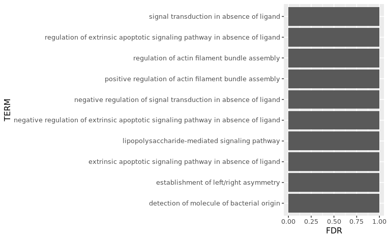

# Enrichment Study-KEGG

```
All input CpGs are used for testing.
```

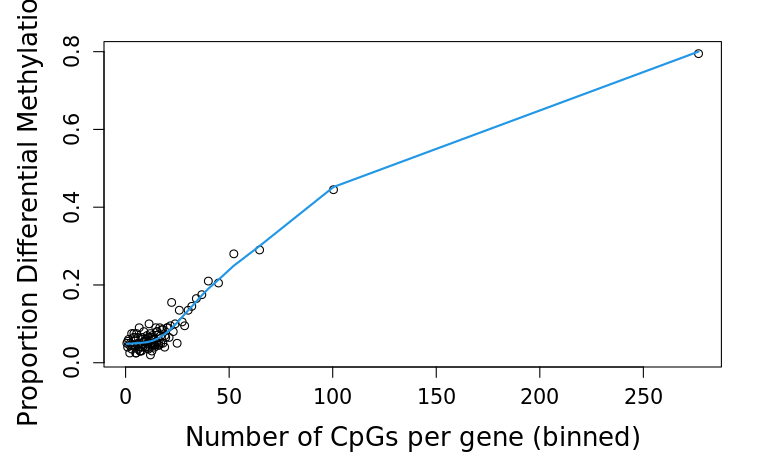

```r
gstKegg <- gometh(sig.cpg=identified.siv, all.cpg=GO.background, collection="KEGG", array.type="EPIC", prior.prob = T, sig.genes = T, plot.bias=TRUE)
```

|  | Description | N | DE | P.DE | FDR | SigGenesInSet |
| --- | --- | --- | --- | --- | --- | --- |
| path:hsa05332 | Graft-versus-host disease | 38 | 12 | 3.594968e-05 | 0.007058741 | HLA-A,HLA-B,HLA-C,HLA-DPA1,HLA-DPB1,HLA-DQA1,HLA-DQB1,HLA-DRA,HLA-DRB1,HLA-DRB5,HLA-E,IL1B |
| path:hsa04940 | Type I diabetes mellitus | 41 | 13 | 5.461323e-05 | 0.007058741 | HLA-A,HLA-B,HLA-C,HLA-DPA1,HLA-DPB1,HLA-DQA1,HLA-DQB1,HLA-DRA,HLA-DRB1,HLA-DRB5,HLA-E,IL1B,PTPRN2 |
| path:hsa05330 | Allograft rejection | 34 | 11 | 8.800129e-05 | 0.007058741 | HLA-A,HLA-B,HLA-C,HLA-DPA1,HLA-DPB1,HLA-DQA1,HLA-DQB1,HLA-DRA,HLA-DRB1,HLA-DRB5,HLA-E |
| path:hsa04659 | Th17 cell differentiation | 103 | 22 | 9.722350e-05 | 0.007058741 | IL17F,CHUK,AHR,HLA-DPA1,HLA-DPB1,HLA-DQA1,HLA-DQB1,HLA-DRA,HLA-DRB1,HLA-DRB5,IL1B,IRF4,JAK2,NFATC1,PLCG1,PRKCQ,RORA,RXRA,ZAP70,RUNX1,CD3D,CD3G,CD247 |
| path:hsa05320 | Autoimmune thyroid disease | 40 | 12 | 1.017110e-04 | 0.007058741 | HLA-A,HLA-B,HLA-C,HLA-DPA1,HLA-DPB1,HLA-DQA1,HLA-DQB1,HLA-DRA,HLA-DRB1,HLA-DRB5,HLA-E,TPO |
| path:hsa04612 | Antigen processing and presentation | 67 | 16 | 1.637681e-04 | 0.009471254 | PSME3,CTSB,HLA-A,HLA-B,HLA-C,HLA-DPA1,HLA-DPB1,HLA-DQA1,HLA-DQB1,HLA-DRA,HLA-DRB1,HLA-DRB5,HLA-E,KIR2DL4,TAP1,TAP2,CD8A |

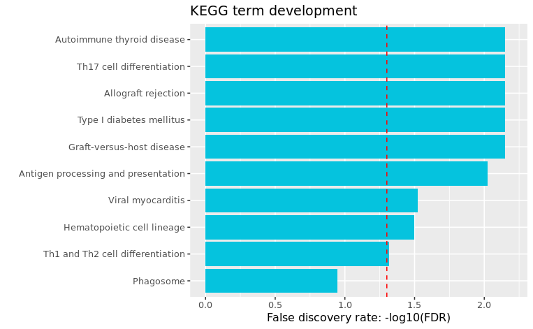

```r
library(GenomicRanges)
library("VennDiagram")
library(readxl)
library(tidyverse)
library(ggvenn)
```

# Proximity analysis

proximity analysis on filtered out sivs

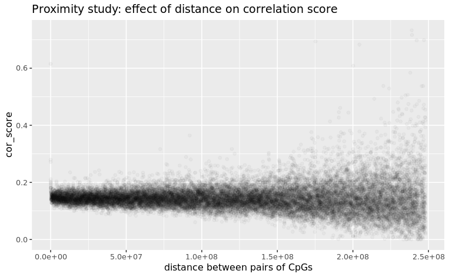

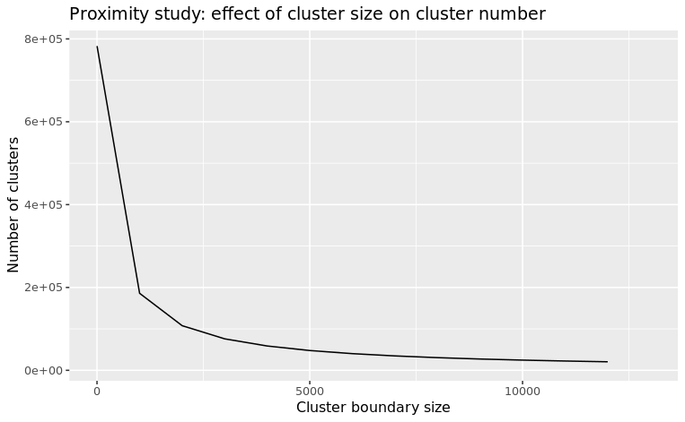

```r
ggplot(prox.df, aes(x=prox.size, y=cluster.no)) + geom_line()+
    ggtitle("Proximity study: effect of cluster size on cluster number") +
  ylab("Number of clusters") +
  xlab("Cluster boundary size") + xlim(0,13000)
```

# Declustering

|  | start | end | width | id | chromosome | cluster_id |
| --- | --- | --- | --- | --- | --- | --- |
| 279 | 613818 | 613819 | 2 | cg12159023 | chr19 | 670 |
| 1298 | 664591 | 664592 | 2 | cg14366095 | chr19 | 670 |
| 1321 | 536581 | 536582 | 2 | cg13467327 | chr19 | 670 |
| 1997 | 613505 | 613506 | 2 | cg17403731 | chr19 | 670 |
| 362 | 1614334 | 1614335 | 2 | cg27071707 | chr19 | 671 |
| 1654 | 7011133 | 7011134 | 2 | cg09208602 | chr19 | 672 |

```r
locs.meta
```

```
GRanges object with 2050 ranges and 1 metadata column:
         seqnames              ranges strand |         cpg
            <Rle>           <IRanges>  <Rle> | <character>
     [1]    chr11   10716592-10716593      * |  cg09840155
     [2]     chr1 236763796-236763797      * |  cg13938504
     [3]     chr5 179038561-179038562      * |  cg13016797
     [4]     chr1   92012148-92012149      * |  cg05527459
     [5]     chr4   10037264-10037265      * |  cg06578786
     ...      ...                 ...    ... .         ...
  [2046]     chr8   41648354-41648355      * |  cg12190407
  [2047]    chr10   96221727-96221728      * |  cg17693266
  [2048]    chr16     8995268-8995269      * |  cg10280091
  [2049]    chr11 118214845-118214846      * |  cg13750061
  [2050]     chr7     2069840-2069841      * |  cg16476700
  -------
  seqinfo: 24 sequences from an unspecified genome; no seqlengths
```

```r
decluster.df$cluster_id %>% unique() %>% length()
```

```
[1] 1463
```

```r
#identifying clusters with >=2 Cpgs
CpG_decluster <- c()
count <- 0
for (x in seq(1, length(unique(cluster.df$cluster_id)))){
  t <- cluster.df %>% filter(cluster_id == unique(cluster.df$cluster_id)[x]) %>% select(id)
  if (length(t[,1]) >=2){
    CpG_decluster <- c(CpG_decluster, t[,1])
    count <- count + 1
  }
}
print(count) #320
length(CpG_decluster) #907

#calculating pairwise average of correlation for each cluster
cor.cluster <- matrix(ncol=2, nrow=0) %>% as.data.frame()

for (x in seq(1, length(unique(cluster.df$cluster_id)))){
  t <- cluster.df %>% filter(cluster_id == unique(cluster.df$cluster_id)[x]) %>% select(id)
  if (length(t[,1]) >=2){
    t1 <- EPIC.norm.beta.DF %>% filter(row.names(EPIC.norm.beta.DF) %in% t[,1])
    t2 <- cor(t(t1), method = c("spearman"))
    a <- (sum(abs(t2)) - dim(t2)[1])/2 #calculating sum of cor (sum of on triangle of the table)
    b <- (dim(t2)[1]^2 - dim(t2)[1])/2 #calculating number of cor (sum of on triangle of the table)
    cor.cluster <- rbind(cor.cluster, c(unique(cluster.df$cluster_id)[x], a/b))
    print(c(x, "/", length(unique(cluster.df$cluster_id))))
  }
}

colnames(cor.cluster) <- c("cluster_id", "cor")

cor.cluster$cor %>% min()
sig.cluster <- cor.cluster %>% filter(cor > 0.5)

list_cor <- c()

for (x in sig.cluster$cluster_id){
  t <- cluster.df %>% filter(cluster_id == x) %>% select(id)

  list_cor <- c(list_cor, t[,1])
}

ggplot(data=cor.cluster, aes(cor.cluster$cor)) +
  geom_histogram(color="white") + ylab("Count") + xlab("Average pairwise correlation score") + geom_vline(xintercept=0.5, color = "red", ) +
  ggtitle("Clusters as measured by Spearman correlation test")

#yet one step further enrichment analysis on the SiV-Cpgs in > 0.5 clusters
sig.cluster %>% head()
sig.list <- decluster.df %>% filter(cluster_id %in% sig.cluster$cluster_id) %>% select(id)
```

```
All input CpGs are used for testing.
```

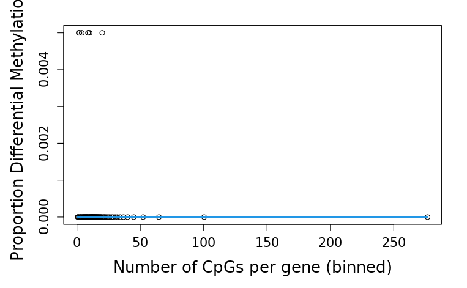

```r
gst.decluster <- gometh(sig.cpg=list_cor, all.cpg=GO.background, collection="GO", array.type="EPIC", prior.prob = T, sig.genes = T, plot.bias=TRUE)
```

[output not shown]

[output cut: 310 more lines]

```
All input CpGs are used for testing.
```

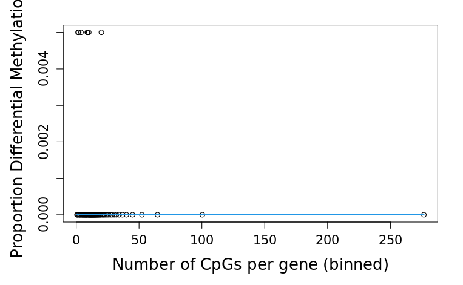

```r
gstkegg.decluster <- gometh(sig.cpg=list_cor, all.cpg=GO.background, collection="KEGG", array.type="EPIC", prior.prob = T, sig.genes = T, plot.bias=TRUE)
```

|  | Description | N | DE | P.DE | FDR | SigGenesInSet |
| --- | --- | --- | --- | --- | --- | --- |
| path:hsa04750 | Inflammatory mediator regulation of TRP channels | 97 | 8 | 0.004621243 | 1 | ADCY7,GNAS,PLA2G4D,IL1B,ITPR3,NGF,P2RY2,PRKCE,PLA2G4C |
| path:hsa04371 | Apelin signaling pathway | 136 | 9 | 0.007314703 | 1 | ADCY7,AKT1,GNG7,ITPR3,BORCS8-MEF2B,MYL4,PRKCE,RYR1,HDAC4 |
| path:hsa04611 | Platelet activation | 123 | 8 | 0.011720577 | 1 | ADCY7,COL1A2,AKT1,GNAS,GP1BA,GP9,PLA2G4D,ITPR3,PLA2G4C |
| path:hsa02010 | ABC transporters | 43 | 4 | 0.017764350 | 1 | ABCB9,ABCD4,ABCG5,ABCG8,TAP2 |
| path:hsa04913 | Ovarian steroidogenesis | 50 | 4 | 0.032458190 | 1 | ADCY7,CYP1B1,GNAS,PLA2G4D,PLA2G4C |
| path:hsa05340 | Primary immunodeficiency | 32 | 3 | 0.033327027 | 1 | TAP2,UNG,ZAP70,CD3D |
| path:hsa04660 | T cell receptor signaling pathway | 99 | 6 | 0.033472811 | 1 | AKT1,PTPN6,TEC,ZAP70,MAP3K14,CD3D,CD3G |
| path:hsa04725 | Cholinergic synapse | 111 | 7 | 0.041396656 | 1 | ADCY7,CHRM3,AKT1,GNG7,ITPR3,KCNQ1,CACNA1B |
| path:hsa04724 | Glutamatergic synapse | 113 | 7 | 0.046229663 | 1 | ADCY7,GNAS,GNG7,PLA2G4D,ITPR3,SLC38A1,SHANK3,PLA2G4C |
| path:hsa04726 | Serotonergic synapse | 108 | 6 | 0.050281565 | 1 | CYP2C18,GNAS,GNG7,PLA2G4D,ITPR3,CACNA1B,PLA2G4C |

[figure not shown]

#yet one step further enrichment analysis on the SiV-Cpgs in > 0.5 clusters

|  | Description | N | DE | P.DE | FDR | SigGenesInSet |
| --- | --- | --- | --- | --- | --- | --- |
| path:hsa04061 | Viral protein interaction with cytokine and cytokine receptor | 96 | 1 | 0.007556657 | 1 | XCR1 |
| path:hsa04062 | Chemokine signaling pathway | 188 | 1 | 0.009016586 | 1 | XCR1 |
| path:hsa04060 | Cytokine-cytokine receptor interaction | 266 | 1 | 0.018853010 | 1 | XCR1 |
| path:hsa00010 | Glycolysis / Gluconeogenesis | 63 | 0 | 1.000000000 | 1 |  |
| path:hsa00020 | Citrate cycle (TCA cycle) | 28 | 0 | 1.000000000 | 1 |  |
| path:hsa00030 | Pentose phosphate pathway | 24 | 0 | 1.000000000 | 1 |  |
| path:hsa00040 | Pentose and glucuronate interconversions | 32 | 0 | 1.000000000 | 1 |  |
| path:hsa00051 | Fructose and mannose metabolism | 32 | 0 | 1.000000000 | 1 |  |
| path:hsa00052 | Galactose metabolism | 28 | 0 | 1.000000000 | 1 |  |
| path:hsa00053 | Ascorbate and aldarate metabolism | 27 | 0 | 1.000000000 | 1 |  |

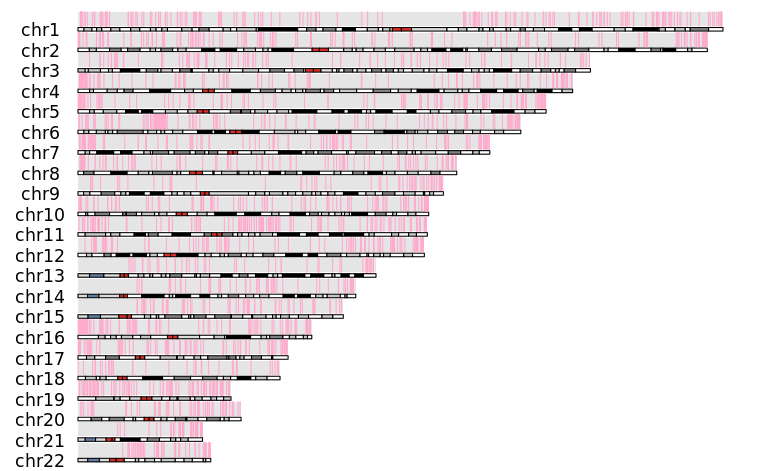

#function for calculating mean, se, 95% CI from a list

```r
print(ci_func(a[!is.na(a)]))
```

[output not shown]

#function that finds out the nearest distance and do bootstrap

```r
    a <- ci_func(b[!is.na(b)])
```

[output not shown]

#erv nearest cpg function

```r
#this function only analysing 1000-10000 by 1000 interval, else code needs to be changes a bit
erv_func <- function(input_file){
  print(input_file)
  #getting the erv file into a df from trans file
  trans <- read.table(input_file,header = FALSE, sep="\t",stringsAsFactors=FALSE, quote="")
  colnames(trans) <- c("chr", "start", "end", "line", "L", "strand", "L_")
  #convert the df into gr object
  transposon.gr <- makeGRangesFromDataFrame(trans,
                           keep.extra.columns=FALSE,
                           ignore.strand=FALSE,
                           seqinfo=NULL,
                           seqnames.field=c("seqnames", "seqname",
                                            "chromosome", "chrom",
                                            "chr", "chromosome_name",
                                            "seqid"),
                           start.field="start",
                           end.field=c("end", "stop"),
                           strand.field="strand",
                           starts.in.df.are.0based=FALSE)

  #run function to get the distance of CpG to the nearest erv for background CpGs
  #776492 here is the total number of CpG in gd
  re.plt.bg <- nearestCpG(row.names(EPIC.norm.beta.DF), dtype="bg", 776492, transposon.gr)
  names(re.plt.bg) <- c("distance", "upper.b", "lower.b", "cu.percent","datatype")

  #run function to get the distance of CpG to the nearest erv for identified HvCpGs
  #2050 here is the total number of CpG in identified SiV
  re.plt.hvcpg <- nearestCpG(var.threshold$probes, dtype="hvCpG", 5464, transposon.gr)
  names(re.plt.hvcpg) <- c("distance", "upper.b", "lower.b", "cu.percent","datatype")

  #combine two dfs
  re.plt.all <- rbind(re.plt.bg, re.plt.hvcpg)

  #double check column names
  names(re.plt.hvcpg)<- c("distance", "upper.b", "lower.b", "cu.percent","datatype")

  #plot bar plot
  ggplot(re.plt.all, aes(x=distance, y=cu.percent, fill=datatype)) +
    geom_bar(position=position_dodge(), stat="identity") +
    geom_errorbar(aes(ymin = lower.b, ymax = upper.b, group=datatype),position=position_dodge(.9)) +
    ylim(0,.5) +
    scale_x_continuous(breaks=seq(1000,10000,1000)) +
    ggtitle("Nearest transposable element to CpG")

  return(re.plt.all)
}
```

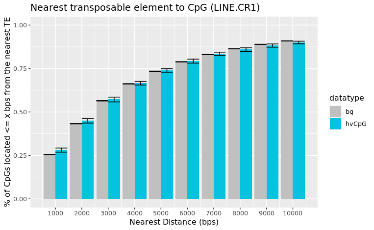